# Los fundamentos de los métodos estadísticos

Para hacer juicios correctos sobre los datos, es necesario procesarlos estadísticamente.

Para ello, es importante comprender los **Métodos estadísticos.**

- Las principales características y propiedades de la distribución normal, una de las distribuciones de datos más comunes, se describen a continuación.
- A continuación se explica la conversión de una distribución normal a una distribución normal estándar.
- Calcular la probabilidad a partir de un valor de una distribución normal y, a la inversa, encontrar el valor de la distribución normal a partir de una probabilidad, utilizando una tabla de distribución normal.
- Características y propiedades de la distribución binomial, que es una distribución de variables discretas (recuento).
- Cálculo de probabilidad de la distribución binomial.

[Audio_1](https://drive.google.com/file/d/1HngX0qEjoNEk-v3BhmUEpWJRZvnFBacN/view?usp=drive_link)

```python
import os

try:
  os.chdir('../Python/QCKentei3')
except:
  pass

path = os.getcwd()
```

```python
import numpy as np
import matplotlib.pyplot as plt
import pandas as pd
from scipy.stats import norm
```

## 04-01 Distribución normal

正規分布

### 1. La distribución normal es:

正規分布とは

Se sabe que la distribución de valores numéricos que se pueden medir (denominados datos continuos o de **medición**), como las dimensiones o el peso, que son características de los productos fabricados en un proceso, muestra que los valores cercanos al centro son más frecuentes, disminuyendo a medida que se alejan del centro hacia la izquierda o la derecha.

Si en el eje horizontal se representan valores medibles, como dimensiones, y en el eje vertical se representa la cantidad (frecuencia), la forma resultante tendrá su punto más alto en el centro y disminuirá a medida que se aleja hacía ambos lados. A este distribución se le llama **distribución normal** y es la más importante en la distribución de valores medibles.

[Audio_2](https://drive.google.com/file/d/1mamoEFcWpJseFDivENXHyE_yxWul7tJh/view?usp=drive_link)

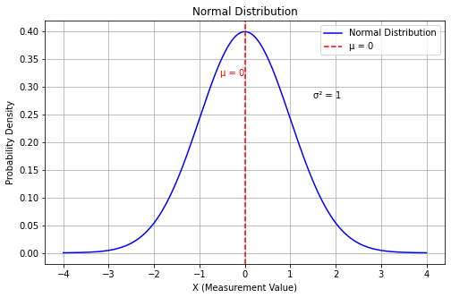

```python
# Configuración de la media poblacional y la varianza poblacional
mu = 0       # Media poblacional (Mean)
sigma = 1    # Desviación estándar poblacional (Standard Deviation)
variance = sigma**2  # Varianza poblacional (Variance)

x = np.linspace(mu - 4*sigma, mu + 4*sigma, 1000)
y = norm.pdf(x, mu, sigma)

# Representación gráfica
plt.figure(figsize=(8, 5))
plt.plot(x, y, label='Normal Distribution', color='blue')
plt.axvline(mu, color='red', linestyle='dashed', label=f'μ = {mu}')
plt.text(mu, max(y) * 0.8, f'μ = {mu}', color='red', ha='right')

plt.text(mu + 1.5, max(y) * 0.7, f'σ² = {variance}', color='black', ha='left')

plt.xlabel('X (Measurement Value)')
plt.ylabel('Probability Density')
plt.title('Normal Distribution')
plt.legend()
plt.grid()
plt.show()
```

La distribución normal se expresa como $ N(\mu, \sigma^2) $. Es decir, el centro de la distribución está en la media poblacional $ \mu $, y la dispersión (amplitud) de la distribución se describe mediante la desviación estándar poblacional $ \sigma $ (o la varianza poblacional $ \sigma^2 $ ).

Todas las distribuciones, incluida la distribución normal, tiene las siguientes propiedades.

- La probabilidad de que ocurra cualquier valor es mayor o igual a 0.
- La probabilidad total dentro del rango de valores posibles es 1(100%).
- La probabilidad de que un valor esté dentro de un cierto intervalo se representa como la proporción del área total, tomando 1(100%) como referencia.

[Audio_3](https://drive.google.com/file/d/1KvOX9ZXxs94YUG1QnR4xJYav6BWr2LOU/view?usp=drive_link)

En la distribución normal, los datos se agrupan cerca del centro, y la cantidad de datos disminuye a medida que nos alejamos del centro hacia la izquierda o la derecha. La probabilidad de que los datos se encuentren dentro de los rangos de $ \pm 1 \sigma $, $ \pm 2 \sigma $ y $ \pm 3 \sigma $ desde el centro $ \mu $ se muestra en la Figura 4.2

- La probabilidad de estar dentro del rango $ \mu \pm 1\sigma => 68.3 $ %
- La probabilidad de estar dentro del rango $ \mu \pm 2\sigma => 95.4 $ %
- La probabilidad de estar dentro del rango $ \mu \pm 3\sigma => 99.7 $ %

[Audio_4](https://drive.google.com/file/d/1ah_IV3IK293CTEZMxiD7-xOK6r9z-T6F/view?usp=drive_link)

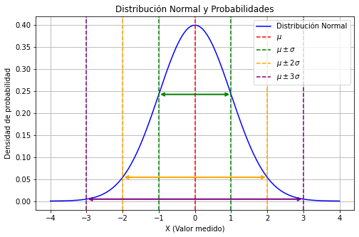

```python
# Representación gráfica
plt.figure(figsize=(8, 5))
plt.plot(x, y, label='Distribución Normal', color='blue')

# μ, μ±σ, μ±2σ, μ±3σ
sigma_levels = [0, 1, 2, 3]
colors = ['red', 'green', 'orange', 'purple']
labels = [r'$\mu$', r'$\mu \pm \sigma$', r'$\mu \pm 2\sigma$', r'$\mu \pm 3\sigma$']

for i, level in enumerate(sigma_levels):
    plt.axvline(mu + level * sigma, color=colors[i], linestyle='dashed', label=labels[i])
    if level != 0:  #
        plt.axvline(mu - level * sigma, color=colors[i], linestyle='dashed')
        plt.annotate('', xy=(mu + i*sigma, norm.pdf(mu + i*sigma, mu, sigma)),
                    xytext=(mu - i*sigma, norm.pdf(mu - i*sigma, mu, sigma)),
                    arrowprops=dict(edgecolor=colors[i], arrowstyle='<->', lw=2))

plt.xlabel('X (Valor medido)')
plt.ylabel('Densidad de probabilidad')
plt.title('Distribución Normal y Probabilidades')
plt.legend()
plt.grid()
plt.show()
```

### 2. Distribución normal estándar

標準正規分布・正規分布表の見方

#### (1) Distribución normal estándar

標準正規分布

Cuando la variable aleatoria $ x $ sigue una distribución normal $ N (\mu, \sigma^2) $, al transformar $ x $ en la variable aleatoria $ u $ de la siguiente manera.

$ u = \frac{x - \mu}{\sigma} $

$ u $ siguió una distribución normal con media 0 y desviación estándar 1. Este proceso de transformación de $ x $ a $ u $ se llama **estandarización (o normalización)**標準化（基準化）. Esta distribución normal se conoce como **distribución normal estándar**（標準正規分布） y se representa como **$ N(0,1^2) $**.

[Audio_5](https://drive.google.com/file/d/1m7bWuPAIay0DfDwCXw1cAidB8Gz3QMtc/view?usp=drive_link)

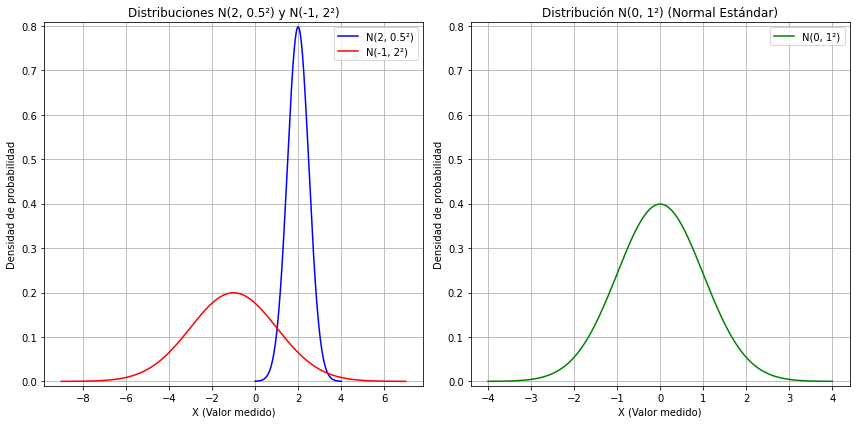

```python
# Configuración de la media porbacional y la desviación estándar
mu_1, sigma_1 = 2, 0.5  # N(2, 0.5²)
mu_2, sigma_2 = -1, 2   # N(-1, 2²)
mu_3, sigma_3 = 0, 1    # N(0, 1²)

x_1 = np.linspace(mu_1 - 4*sigma_1, mu_1 + 4*sigma_1, 1000)
x_2 = np.linspace(mu_2 - 4*sigma_2, mu_2 + 4*sigma_2, 1000)
x_3 = np.linspace(mu_3 - 4*sigma_3, mu_3 + 4*sigma_3, 1000)

# Función de densidad de probabilidad de la distribución normal
y_1 = norm.pdf(x_1, mu_1, sigma_1)
y_2 = norm.pdf(x_2, mu_2, sigma_2)
y_3 = norm.pdf(x_3, mu_3, sigma_3)

fig, axs = plt.subplots(1, 2, figsize=(12, 6))

# (N(2, 0.5²) y N(-1, 2²))
axs[0].plot(x_1, y_1, label='N(2, 0.5²)', color='blue')
axs[0].plot(x_2, y_2, label='N(-1, 2²)', color='red')
axs[0].set_title('Distribuciones N(2, 0.5²) y N(-1, 2²)')
axs[0].set_xlabel('X (Valor medido)')
axs[0].set_ylabel('Densidad de probabilidad')
axs[0].legend()
axs[0].grid()

# N(0, 1)
axs[1].plot(x_3, y_3, label='N(0, 1²)', color='green')
axs[1].set_title('Distribución N(0, 1²) (Normal Estándar)')
axs[1].set_xlabel('X (Valor medido)')
axs[1].set_ylabel('Densidad de probabilidad')
axs[1].legend()
axs[1].grid()

y_max = max(max(y_1), max(y_2), max(y_3))
y_min = min(min(y_1), min(y_2), min(y_3))

for ax in axs:
    ax.set_ylim(y_min - 0.01, y_max + 0.01)

plt.tight_layout()
plt.show()
```

#### (2) Tabla de la distribución normal

正規分布表

1. Tabla de distribución normal I, donde se obtiene P a partir de Kp

```python
pd.options.display.float_format = '{:.4f}'.format

prob_values = []
for i in np.arange(0, 3.1, 0.01):
      prob_values.append(1- norm.cdf(i))

df = pd.DataFrame(np.array(prob_values).reshape(31,10))
df.index = np.arange(0.0, 3.1, 0.1)

prob = []
for i in np.arange(3.5,6.0,0.5):
      prob.append(1- norm.cdf(i))

df2 = pd.DataFrame({0:prob},index=np.arange(3.5,6.0,0.5))

df3 = pd.concat([df,df2])

df3.to_excel('Data3/TablaDistribucionNormal_2.xlsx')
df3
```

|  | 0 | 1 | 2 | 3 | 4 | 5 | 6 | 7 | 8 | 9 |
| --- | --- | --- | --- | --- | --- | --- | --- | --- | --- | --- |
| 0.0000 | 0.5000 | 0.4960 | 0.4920 | 0.4880 | 0.4840 | 0.4801 | 0.4761 | 0.4721 | 0.4681 | 0.4641 |
| 0.1000 | 0.4602 | 0.4562 | 0.4522 | 0.4483 | 0.4443 | 0.4404 | 0.4364 | 0.4325 | 0.4286 | 0.4247 |
| 0.2000 | 0.4207 | 0.4168 | 0.4129 | 0.4090 | 0.4052 | 0.4013 | 0.3974 | 0.3936 | 0.3897 | 0.3859 |
| 0.3000 | 0.3821 | 0.3783 | 0.3745 | 0.3707 | 0.3669 | 0.3632 | 0.3594 | 0.3557 | 0.3520 | 0.3483 |
| 0.4000 | 0.3446 | 0.3409 | 0.3372 | 0.3336 | 0.3300 | 0.3264 | 0.3228 | 0.3192 | 0.3156 | 0.3121 |
| 0.5000 | 0.3085 | 0.3050 | 0.3015 | 0.2981 | 0.2946 | 0.2912 | 0.2877 | 0.2843 | 0.2810 | 0.2776 |
| 0.6000 | 0.2743 | 0.2709 | 0.2676 | 0.2643 | 0.2611 | 0.2578 | 0.2546 | 0.2514 | 0.2483 | 0.2451 |
| 0.7000 | 0.2420 | 0.2389 | 0.2358 | 0.2327 | 0.2296 | 0.2266 | 0.2236 | 0.2206 | 0.2177 | 0.2148 |
| 0.8000 | 0.2119 | 0.2090 | 0.2061 | 0.2033 | 0.2005 | 0.1977 | 0.1949 | 0.1922 | 0.1894 | 0.1867 |
| 0.9000 | 0.1841 | 0.1814 | 0.1788 | 0.1762 | 0.1736 | 0.1711 | 0.1685 | 0.1660 | 0.1635 | 0.1611 |
| 1.0000 | 0.1587 | 0.1562 | 0.1539 | 0.1515 | 0.1492 | 0.1469 | 0.1446 | 0.1423 | 0.1401 | 0.1379 |
| 1.1000 | 0.1357 | 0.1335 | 0.1314 | 0.1292 | 0.1271 | 0.1251 | 0.1230 | 0.1210 | 0.1190 | 0.1170 |
| 1.2000 | 0.1151 | 0.1131 | 0.1112 | 0.1093 | 0.1075 | 0.1056 | 0.1038 | 0.1020 | 0.1003 | 0.0985 |
| 1.3000 | 0.0968 | 0.0951 | 0.0934 | 0.0918 | 0.0901 | 0.0885 | 0.0869 | 0.0853 | 0.0838 | 0.0823 |
| 1.4000 | 0.0808 | 0.0793 | 0.0778 | 0.0764 | 0.0749 | 0.0735 | 0.0721 | 0.0708 | 0.0694 | 0.0681 |
| 1.5000 | 0.0668 | 0.0655 | 0.0643 | 0.0630 | 0.0618 | 0.0606 | 0.0594 | 0.0582 | 0.0571 | 0.0559 |
| 1.6000 | 0.0548 | 0.0537 | 0.0526 | 0.0516 | 0.0505 | 0.0495 | 0.0485 | 0.0475 | 0.0465 | 0.0455 |
| 1.7000 | 0.0446 | 0.0436 | 0.0427 | 0.0418 | 0.0409 | 0.0401 | 0.0392 | 0.0384 | 0.0375 | 0.0367 |
| 1.8000 | 0.0359 | 0.0351 | 0.0344 | 0.0336 | 0.0329 | 0.0322 | 0.0314 | 0.0307 | 0.0301 | 0.0294 |
| 1.9000 | 0.0287 | 0.0281 | 0.0274 | 0.0268 | 0.0262 | 0.0256 | 0.0250 | 0.0244 | 0.0239 | 0.0233 |
| 2.0000 | 0.0228 | 0.0222 | 0.0217 | 0.0212 | 0.0207 | 0.0202 | 0.0197 | 0.0192 | 0.0188 | 0.0183 |
| 2.1000 | 0.0179 | 0.0174 | 0.0170 | 0.0166 | 0.0162 | 0.0158 | 0.0154 | 0.0150 | 0.0146 | 0.0143 |
| 2.2000 | 0.0139 | 0.0136 | 0.0132 | 0.0129 | 0.0125 | 0.0122 | 0.0119 | 0.0116 | 0.0113 | 0.0110 |
| 2.3000 | 0.0107 | 0.0104 | 0.0102 | 0.0099 | 0.0096 | 0.0094 | 0.0091 | 0.0089 | 0.0087 | 0.0084 |
| 2.4000 | 0.0082 | 0.0080 | 0.0078 | 0.0075 | 0.0073 | 0.0071 | 0.0069 | 0.0068 | 0.0066 | 0.0064 |
| 2.5000 | 0.0062 | 0.0060 | 0.0059 | 0.0057 | 0.0055 | 0.0054 | 0.0052 | 0.0051 | 0.0049 | 0.0048 |
| 2.6000 | 0.0047 | 0.0045 | 0.0044 | 0.0043 | 0.0041 | 0.0040 | 0.0039 | 0.0038 | 0.0037 | 0.0036 |
| 2.7000 | 0.0035 | 0.0034 | 0.0033 | 0.0032 | 0.0031 | 0.0030 | 0.0029 | 0.0028 | 0.0027 | 0.0026 |
| 2.8000 | 0.0026 | 0.0025 | 0.0024 | 0.0023 | 0.0023 | 0.0022 | 0.0021 | 0.0021 | 0.0020 | 0.0019 |
| 2.9000 | 0.0019 | 0.0018 | 0.0018 | 0.0017 | 0.0016 | 0.0016 | 0.0015 | 0.0015 | 0.0014 | 0.0014 |
| 3.0000 | 0.0013 | 0.0013 | 0.0013 | 0.0012 | 0.0012 | 0.0011 | 0.0011 | 0.0011 | 0.0010 | 0.0010 |
| 3.5000 | 0.0002 | NaN | NaN | NaN | NaN | NaN | NaN | NaN | NaN | NaN |
| 4.0000 | 0.0000 | NaN | NaN | NaN | NaN | NaN | NaN | NaN | NaN | NaN |
| 4.5000 | 0.0000 | NaN | NaN | NaN | NaN | NaN | NaN | NaN | NaN | NaN |
| 5.0000 | 0.0000 | NaN | NaN | NaN | NaN | NaN | NaN | NaN | NaN | NaN |
| 5.5000 | 0.0000 | NaN | NaN | NaN | NaN | NaN | NaN | NaN | NaN | NaN |

1. Tabla de distribución normal II, donde se obtiene Kp a partir de P

```python
fp = []
for p in np.arange(0,0.01,0.001):
  fp.append(-norm.ppf(p))

for p in np.arange(0,0.5,0.01):
  fp.append(-norm.ppf(p))

df = pd.DataFrame(np.array(fp).reshape(6,10))
ind = ['0.00','0.0','0.1','0.2','0.3','0.4']
df.index = ind

df.to_excel('Data3/TablaDistribucionNormal2.xlsx')
df
```

|  | 0 | 1 | 2 | 3 | 4 | 5 | 6 | 7 | 8 | 9 |
| --- | --- | --- | --- | --- | --- | --- | --- | --- | --- | --- |
| 0.00 | inf | 3.0902 | 2.8782 | 2.7478 | 2.6521 | 2.5758 | 2.5121 | 2.4573 | 2.4089 | 2.3656 |
| 0.0 | inf | 2.3263 | 2.0537 | 1.8808 | 1.7507 | 1.6449 | 1.5548 | 1.4758 | 1.4051 | 1.3408 |
| 0.1 | 1.2816 | 1.2265 | 1.1750 | 1.1264 | 1.0803 | 1.0364 | 0.9945 | 0.9542 | 0.9154 | 0.8779 |
| 0.2 | 0.8416 | 0.8064 | 0.7722 | 0.7388 | 0.7063 | 0.6745 | 0.6433 | 0.6128 | 0.5828 | 0.5534 |
| 0.3 | 0.5244 | 0.4959 | 0.4677 | 0.4399 | 0.4125 | 0.3853 | 0.3585 | 0.3319 | 0.3055 | 0.2793 |
| 0.4 | 0.2533 | 0.2275 | 0.2019 | 0.1764 | 0.1510 | 0.1257 | 0.1004 | 0.0753 | 0.0502 | 0.0251 |

La distribución normal estándar es simétrica respecto a $ u=0 $, por lo que el valor correspondiente a una probabilidad acumulada (probabilidad de que la variable aleatoria sea menor 0 igual a un valor) P es -Kp. Es decir, la probabilidad de que la variable aleatoria sea menor o igual a -Kp es P.

[Audio_8](https://drive.google.com/file/d/1FAlLV1VTX9CHJk3k9yFp-F8b0SguCi2k/view?usp=drive_link)

### 4.1

標準正規分布の確率Pと対応する値Kpのを求めよ。

P:[0.5, 0.10, 0.05] の時のKp

Kp:[1.96, 2.23, 2.95]の時のP

Encuentre el valor de Kp correspondiente a la probabilidad P de la distribución normal estándar.

P:[0.5, 0.10, 0.05], ¿cuáles son los valores de Kp correspondientes?

Kp:[1.96, 2.23, 2.95], ¿cuáles son las probabilidades P correspondientes?

```python
import scipy.stats as stats

# Encontrar el valor de Kp correspondiente a P
P_values = [0.5, 0.10, 0.05]
Kp_values = [stats.norm.ppf(P) for P in P_values]

# Encontrar el valor de P correspondiente a Kp
Kp_values2 = [1.96, 2.23, 2.95]
P_values2 = [1 - stats.norm.cdf(Kp) for Kp in Kp_values2]

#
print("Resultados de encontrar Kp a partir de P:")
for P, Kp in zip(P_values, Kp_values):
    print(f"P = {P} -> Kp = {Kp:.2f}")

print("\nResultados de encontrar P a partir de Kp:")
for Kp, P in zip(Kp_values2, P_values2):
    print(f"Kp = {Kp} -> P = {P:.4f}")
```

```
Resultados de encontrar Kp a partir de P:
P = 0.5 -> Kp = 0.00
P = 0.1 -> Kp = -1.28
P = 0.05 -> Kp = -1.64

Resultados de encontrar P a partir de Kp:
Kp = 1.96 -> P = 0.0250
Kp = 2.23 -> P = 0.0129
Kp = 2.95 -> P = 0.0016
```

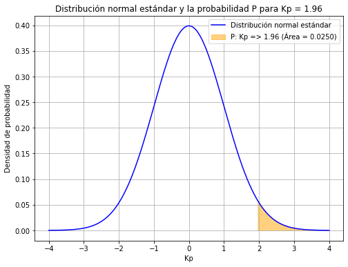

```python
x = np.linspace(-4, 4, 1000)  #
y = stats.norm.pdf(x)  #

Kp_value = 1.96
P_value = 1 - stats.norm.cdf(Kp_value)

plt.figure(figsize=(8, 6))

plt.plot(x, y, label="Distribución normal estándar", color='blue')
plt.fill_between(x, 0, y, where=(x >= Kp_value), color='orange', alpha=0.5, label=f'P: Kp => {Kp_value} (Área = {P_value:.4f})')
plt.title("Distribución normal estándar y la probabilidad P para Kp = 1.96")
plt.xlabel("Kp")
plt.ylabel("Densidad de probabilidad")
plt.legend()

plt.grid(True)
plt.show()
```

### 4.2

標準正規分布において

1. Kpが-3.0から2.0の間の確率Pをもとめよ。
2. Kpが-2.0から-1.0の間の確率Pを求めよ。

En la distribución normal estándar.

1. Encuentra la probabilidad $ P $ entre $ Kp = -3.0 $ y $ Kp = 2.0 $
2. Encuentra la probabilidad $ P $ entre $ Kp = -2.0 $ y $ Kp=-1.0 $.

```
Probabilidad P cuand Kp está enter -3.0 y 2.0: 0.9759
Probabilidad P cuand Kp está entre -2.0 y -1.0: 0.1359
```

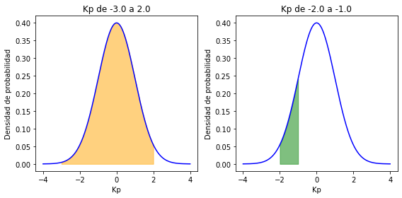

```python
# 1. Calcular la probabilidad P cuand Kp está enter -3.0 y 2.0
P_1 = stats.norm.cdf(2.0) - stats.norm.cdf(-3.0)

# 2. Calcular la probabilidad P cuand Kp está entre -2.0 y -1.0
P_2 = stats.norm.cdf(-1) - stats.norm.cdf(-2)

#
print(f"Probabilidad P cuand Kp está enter -3.0 y 2.0: {P_1:.4f}")
print(f"Probabilidad P cuand Kp está entre -2.0 y -1.0: {P_2:.4f}")

#
x = np.linspace(-4, 4, 1000)
y = stats.norm.pdf(x)  #

fig, axs = plt.subplots(1, 2, figsize=(8, 4))

axs[0].plot(x, y, label="Distribución normal estándar", color='blue')
axs[0].fill_between(x, 0, y, where=(x >= -3.0) & (x <= 2.0), color='orange', alpha=0.5)
axs[0].set_title("Kp de -3.0 a 2.0")
axs[0].set_xlabel("Kp")
axs[0].set_ylabel("Densidad de probabilidad")

axs[1].plot(x, y, label="Distribución normal estándar", color='blue')
axs[1].fill_between(x, 0, y, where=(x >= -2) & (x <= -1), color='green', alpha=0.5)
axs[1].set_title("Kp de -2.0 a -1.0")
axs[1].set_xlabel("Kp")
axs[1].set_ylabel("Densidad de probabilidad")

plt.tight_layout()
plt.show()
```

### 3. Probabilidad de la distribución normal

正規分布の確率

#### (1) Método para calcular la probabilidad P a partir de una variable x que sigue una distribución normal

正規分布に従う変数ｘから確率Ｐを求める方法

### 4.3

ある部品の重量（単位：ｇ）は、正規分布 $ N(50.0, 0.20^2) $ に従っている。この時重量が50.5以上になる確率を求めよ。

El peso de una pieza (unidad: g) sigue una distribución normal $ N(50.0, 0.20^2) $. Calcule la probabilidad de que el peso sea mayor o igual a 50.5.

```python
# Parámetros de la distribución normal
mu = 50.0      # Media poblacional
sigma = 0.20  # Desviación estándar poblacional

# Peso que se desea calcular
x = 50.5

# Calcular la probabilidad de que s sea mayor o igual 50.5
 # en una distribución normal N(mu, sigma^2)
probability = 1 - stats.norm.cdf(x, loc=mu, scale=sigma)

print(f"Probabilidad de que el peso sea mayor o igual a 50.5: {probability*100:.2f}%")
```

```
Probabilidad de que el peso sea mayor o igual a 50.5: 0.62%
```

#### (2) Método para calcular la variable x a partir de la probabilidad P en una distribución normal

正規分布に従う確率Ｐから変数ｘを求める方法

### 4.4

ある部品の重量（単位：ｇ）は、正規分布 $ N(50.0, 0.20^2) $ に従っている。この時重量が50.5以上になる確率を０．１％以下にしたい。母平均は変わらないとして、母標準偏差をいくつにすればよいか。

El peso de una pieza (en gramos) sigue una distribución normal $ N(50.0, 0.20^2) $. Se desea que la probabilidad de que el peso sea mayor o igual a 50.5 sea menor o igual al 0.1%. Si la media poblacional no cambia, ¿qué valor debe tener la desviación estándar poblacional?

```python
# Media poblacional
mu = 50.0

# Probabilidad objetivo P（0.1% = 0.001）
P = 0.001

# Desviación estándar actual
current_sigma = 0.20

# Calcular el valor z cuando x = 50.
x = 50.5

# Calcular el valor z (obtenido mediante la función inversa
# de la distribución acumulada para P=0.001)
z = stats.norm.ppf(1 - P)  #

# Calcular la nueva desviación estándar
new_sigma = (x - mu) / z

print(f"La desviación estándar poblacional es {new_sigma:.3f}g ")
```

```
La disviación estándar poblacional es 0.162g
```

### 4.5

ある工場で生産されている精密部品の長さ（単位: $ \mu m $ )は、正規分布 $ N(800.0, 3.0^2) $ に従っている。また、現在の規格値は上限規格808.0($ \mu m $)、下限規格792.0($ \mu m $)である。

1. 現在の製品規格外れが発生する確率を求めよ。
2. お客様からの要望によって、下限規格だけが796.0に変更された。この時の下限規格外れが発生する確率を求めよ。
3. 規格変更後の規格外れを小さくするため、母平均が802.0になるように調整を行った。母標準偏差は変わらないとして、この時の製品規格外れが発生する確率を求めよ。
4. 規格変更後の規格外れの発生確率を1.0%以下にするため、母平均は802.0のまま、母標準偏差を小さくしたい。いくらにすればよいか求めよ。

En una fábrica, la longitud de la piezas de precisión producidas (unidad: $ \mu m $) sigue una distribución normal $ N(800.0, 3.0^2) $. Además, los valores actuales de especificación son un límite superior de 808.0($ \mu m $) y un límite inferior de 792.0 ($ \mu m $).

1. Calcula la probabilidad de que un producto quede fuera de las especificaciones actuales.
2. Debido a una solicitud del cliente, solo el límite inferior se cambió a 796.0. Calcula la probabilidad de que un producto quede fuera de este nuevo límite inferior.
3. Para reducir la proporción de productos fuera de especificaciones después del cambio, se ajustó la media poblacional a 802.0, manteniendo la misma desviación estándar. Calcula la probabilidad de que un producto quede fuera de las especificaciones en esta nueva condición.
4. Para reducir la probabilidad de productos fuera de especificaciones a menos del 1.0%, se desea disminuir la desviación estándar, manteniendo la media poblacional en 802.0. Calcula el valor necesario de la desviación estándar.

```python
def calculate_out_of_spec_prob(mean, std_dev, lower_limit, upper_limit):
    """
    Calcular la probabilidad de estar fuera de especificación
    """
    prob_lower = stats.norm.cdf(lower_limit, loc=mean, scale=std_dev)
    prob_upper = 1 - stats.norm.cdf(upper_limit, loc=mean, scale=std_dev)
    return prob_lower + prob_upper

def find_required_std(mean, lower_limit, upper_limit, target_prob):
    """
    Determinar la desviación estándar para que la probabilidad de estar
    fuera de especificaciones sea menor o igual a target_prob
    """
    z_lower = stats.norm.ppf(target_prob / 2)
    z_upper = stats.norm.ppf(1 - target_prob / 2)
    std_dev_lower = (mean - lower_limit) / abs(z_lower)
    std_dev_upper = (upper_limit - mean) / abs(z_upper)
    return min(std_dev_lower, std_dev_upper)

# Condiciones
mean_0 = 800.0  # Media poblacional inicial
std_dev_0 = 3.0  # Desviación estándar poblacional inicial
lower_limit_0 = 792.0  # Límite inferior inicial de especificación
upper_limit_0 = 808.0  # Límite superior inicial de especificación

# 1. Probabilidad actual de estar fuera de especificación
prob_1 = calculate_out_of_spec_prob(mean_0, std_dev_0, lower_limit_0, upper_limit_0)
print(f"1. Probabilidad actual de estar fuera de especificación: {prob_1*100:.2f}%")

# 2. Probabilidad de estar fuera de especificación cuando el límite inferior se cambió a 796.0
lower_limit_2 = 796.0
prob_lower = stats.norm.cdf(lower_limit_2, loc=mean_0, scale=std_dev_0)
print(f"2. Probabilidad de no conformidad en el límite inferior \n   después del cambio en la especificación inferior: {prob_lower*100:.2f}%")

# 3. Probabilidad de estar fuera de especificación cuando la media poblacional se ajusta a 802.0
mean_3 = 802.0
prob_3 = calculate_out_of_spec_prob(mean_3, std_dev_0, lower_limit_2, upper_limit_0)
print(f"3. Probabilidad de estar fuera de especificación después del cambio \n   de especificación (media poblacional de 802.0): {prob_3*100:.2f}%")

# 4. Desviación estándar necesaria par que la probabilidad de estar fuera de especificación sea del 1.0% o menor
target_prob = 0.01
std_dev_4 = find_required_std(mean_3, lower_limit_2, upper_limit_0, target_prob)
print(f"4. Desviación estándar necesaria para que la probabilidad de estar \n   fuera de especificación sea del 1.0%: {std_dev_4:.1f}")
```

```
1. Probabilidad actual de estar fuera de especificación: 0.77%
2. Probabilidad de no conformidad en el límite inferior
   después del camibo en la especificación inferior: 9.12%
3. Probabilidad de estar fuera de especificación después del camibo
   de especificación (media poblacional de 802.0): 4.55%
4. Desviación estandar necesaria para que la probabilidad de estar
   fuera de especificación sea del 1.0%: 2.3
```

## 04-02 Distribución binomial

二項分布

### 1. La distribución binomial es:

二項分布 Los datos de conteo que toman valores discontinuos generalmente siguen una distribución diferente a la normal. Una de las distribuciones representativas de este tipo es la **distribución binomial**.

[Audio_6](https://drive.google.com/file/d/1aSu-N6kmlap2YkVrLQ6HJJ1aS0Fj2dOy/view?usp=drive_link)

Una gran caja contiene piedras blancas y negras de la misma forma y tamaño, con una cantidad igual de cada tipo, bien mezcladas. Cuando se extraen 10 piedras de la caja con los ojos cerrados, ¿cuál es la distribución de probabilidad del número de piedras blancas extraídas?

Si se realiza varias veces, es probable que se obtenga un número diferente cada vez. Sin embargo, aunque se espera que tome un valor entre 0 y 10, es raro que sea 0 o 10, y parece que alrededor de 5 es lo más frecuente. La distribución de probabilidad del número de piedras blancas en casos como este el la **distribución binomial**.

Generalmente, el número de artículos no conformes que ocurren en un proceso de fabricación sigue una distribución binomial. Cuando se toma una muestra aleatoria de n elementos de un proceso con una proporción de no conformidades poblacional P, la probabilidad P(x) de que haya x artículos no conformes en la muestra se puede calcular con la siguiente fórmula:

$ P_x = {}_n C_x P^x (1-P)^{n-x} = \frac{n!}{x!(n-x)!} P^x(1-P)^{n-x} $

La distribución binomial es una distribución de probabilidad con una media poblacional de nP y una varianza poblacional de nP(1-P). Es decir, la distribución binomial queda completamente definida una vez que se conoce la proporción de no conformidades poblacional P. Además, el parámetro P no se limita a la proporción de no conformidades o la tasa de defectos; puede ser cualquier cosa que se pueda clasificar en dos valores, como la tasa de aprobación de un gabinete o la tasa de victorias deportivas.

[Audio_7](https://drive.google.com/file/d/1aJIbWpApwOYg6lpPeCw5Fs0eJN3v89Oe/view?usp=drive_link)

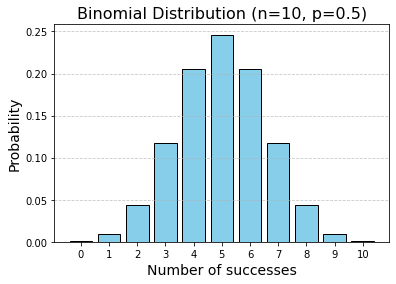

```python
from scipy.stats import binom

# Configuración de parámetros
n = 10  # Número de intentos
p = 0.5  # Probabilidad de éxito

# Rango de x（número de éxitos）
x = np.arange(0, n+1)

# Función de masa de probabilidad de la distribución（PMF）
pmf = binom.pmf(x, n, p)

plt.figure(figsize=(6, 4))
plt.bar(x, pmf, color='skyblue', edgecolor='black')

plt.title(f'Binomial Distribution (n={n}, p={p})', fontsize=16)
plt.xlabel('Number of successes', fontsize=14)
plt.ylabel('Probability', fontsize=14)

plt.xticks(np.arange(0, n+1, 1))
plt.grid(axis='y', linestyle='--', alpha=0.7)

plt.show()
```

### 4.6

母不適合品率P=0.10の工程から、サンプルを５個抜き取ったとき、サンプル中の不適合が２個以下である確率を求めよ。

Calcule la probabilidad de que haya 2 o menos unidades no conformes en una muestra de 5 unidades extraídas de un proceso con una tasa de no conformidad poblacional de $ P=0.10 $.

```
Probabilidad de que haya 2 o menos productos defectuosos: 0.991
```

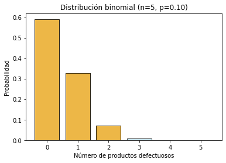

```python
from scipy.stats import binom

# Configuración de parámetros
n = 5   # Número de muestras
p = 0.10  # Tasa de productos defectuosos de la población

# Cálculo de la probabilidad (de 0,1,2 productos defectuosos o menos)
k_values = np.arange(0, 3)  # 0, 1, 2
prob = binom.cdf(2, n, p)  # P(X <= 2)
print(f"Probabilidad de que haya 2 o menos productos defectuosos: {prob:.3f}")

# グラフ描画
x = np.arange(0, n+1)
y = binom.pmf(x, n, p)

plt.bar(x, y, color='lightblue', alpha=0.7, edgecolor='black')
plt.xlabel("Número de productos defectuosos")
plt.ylabel("Probabilidad")
plt.title("Distribución binomial (n=5, p=0.10)")
plt.xticks(x)

plt.bar(k_values, binom.pmf(k_values, n, p), color='orange', alpha=0.7, edgecolor='black')

plt.show()
```

## Por favor, responda a las preguntas del examen de práctica a través del siguiente enlace.

[Simulacro de examen](https://forms.gle/62psQhGoHn1ExpT39)

## 9.1

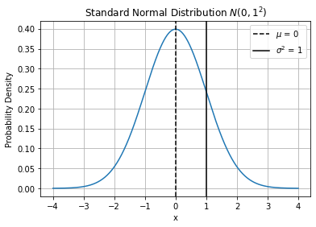

```python
import numpy as np
import matplotlib.pyplot as plt

# 標準正規分布のパラメータ
mean = 0
std_dev = 1

# x軸の範囲を設定
x = np.linspace(-4, 4, 1000)

# 標準正規分布の確率密度関数を計算
y = (1 / (std_dev * np.sqrt(2 * np.pi))) * np.exp(-0.5 * ((x - mean) / std_dev) ** 2)


# プロット
plt.plot(x, y)
plt.axvline(x=0, color='k', linestyle='--', label=r'$ \mu $ = 0' )
plt.axvline(x=1, color='k', linestyle='-', label=r'$ \sigma^2 $ = 1')
plt.title(r'Standard Normal Distribution $ N(0,1^2) $')
plt.xlabel('x')
plt.ylabel('Probability Density')
plt.legend()
plt.grid(True)
plt.show()
```

```python
notebook_name = 'QCKentei3-4.ipynb'
notebook_name_html = notebook_name.replace(".ipynb",".html")

!jupyter nbconvert --to html  {notebook_name}
```

```
[NbConvertApp] Converting notebook QCKentei3-4.ipynb to html
[NbConvertApp] Writing 908156 bytes to QCKentei3-4.html
```